Realizado por:

*Sergio Ranz Casado*  
*Marcos Medina Cogolludo*

# 1.3. ANALISIS EDA ACCIDENTES DE TRÁFICO (DATASET AGRUPADO).

**Análisis de accidentes/muertes por accidente.** Queremos enfocar nuestro análisis a los accidentes de trafico y muertes sobre las diferentes variables de collision. Respondemos a las siguientes cuestiones:

1. *Evolución accidentes y muertos a lo largo de los periodos.*
2. *Análisis de la correlacción de las muertes con los accidentes.*
3. *¿En que carreteras es mas probable tener accidentes? ¿En que tipo de carretera es mas probable fallecer?*
4. *¿Qué dias a la semana suelen tener accidentes? ¿Que dia de la semana hay mas fallecidos?*
5. *¿Con qué tipos de clima es mas probable tener accidentes? ¿En que superficie es mas probable tener accidentes? Correlacción clima con superficie, análisis tipo de clima y tipo de calzada vs mortalidad.*
6. *¿Que tipos de vehiculos son mas propensos a tener accidentes mortales? Año del vehiculo.*
7. *¿Qué tipos de conductores son mas propensos a tener accidentes mortales? Sexo, edad, tipo de conductor.*
8. *¿Qué posición dentro del habitaculo del vehiculo es mas mortal?.*
9. *Tipo de colisión y mortalidad.*
10. *Uso mecanismos de seguridad vs mortalidad.*

#### IMPORTACIÓN DE LIBRERIAS

```python
import pandas as pd
import pyarrow.csv as pv
import pyarrow.parquet as pq
import seaborn as sns
import numpy as np
from matplotlib import pyplot as plt
```

#### IMPORTAMOS FUNCIONES:

```python
def plot_analisis (data, title, rot):
    '''Dibujamos el grafico para mostrar la relacción de accidentes con tipo de carretera'''

    fig,ax1 = plt.subplots()
    ax1.tick_params(grid_alpha=0)
    ax2 = ax1.twinx()
    ax2.tick_params(grid_alpha=0)
    ax2.set_ylabel('Percentaje de mortalidad', color="red")

    data.plot(kind="bar",rot=rot, log=True,color=['orange','navy'],figsize=(15,6),title=title, ax=ax1)

    '''Dubujamos la Linea de mortalidad:'''

    linea_mortalidad = data["Muertos"]/(data["Muertos"] + data["No Muertos"])*100
    linea_mortalidad.plot(c="red", style="o--", ax=ax2)
```

#### IMPORTAMOS EL DATASET

```python
df_acc = pd.read_parquet('../data/df_acc_1.parquet')
df_acc
```

|  | c_year | c_mnth | c_wday | c_hour | c_sev | c_vehs | c_conf | c_rcfg | c_wthr | c_rsur | c_raln | c_traf | c_nums |
| --- | --- | --- | --- | --- | --- | --- | --- | --- | --- | --- | --- | --- | --- |
| 0 | 1999 | 01 | 1 | 00 | 2 | 01 | 01 | 01 | 1 | 4 | 1 | 18 | 1 |
| 1 | 1999 | 01 | 1 | 00 | 2 | 01 | 01 | 01 | 1 | 5 | 1 | 18 | 1 |
| 2 | 1999 | 01 | 1 | 00 | 2 | 01 | 01 | 01 | 2 | 1 | 1 | 18 | 1 |
| 3 | 1999 | 01 | 1 | 00 | 2 | 01 | 01 | 01 | 6 | 3 | 2 | 18 | 2 |
| 4 | 1999 | 01 | 1 | 00 | 2 | 01 | 01 | UU | 1 | 2 | 3 | 18 | 1 |
| ... | ... | ... | ... | ... | ... | ... | ... | ... | ... | ... | ... | ... | ... |
| 1850312 | 2014 | 12 | 7 | UU | 2 | 02 | UU | 02 | U | U | 1 | 03 | 2 |
| 1850313 | 2014 | UU | U | 14 | 2 | 01 | 02 | 01 | 1 | 5 | 4 | 18 | 1 |
| 1850314 | 2014 | UU | U | 22 | 1 | 01 | 06 | 01 | 2 | 4 | Q | 18 | 2 |
| 1850315 | 2014 | UU | U | 23 | 2 | 01 | 06 | 05 | 1 | 1 | U | 18 | 1 |
| 1850316 | 2014 | UU | U | UU | 2 | UU | UU | 01 | U | U | U | UU | 20 |

1850317 rows × 13 columns

```python
df_acc_p = df_acc[:]
df_acc_p[['c_mnth','c_wday']] = df_acc_p[['c_mnth','c_wday']].replace('[^0-9]+',np.nan,regex=True)
df_acc_p.dropna(axis=0,subset=['c_mnth','c_wday'],inplace=True)

df_acc_p
```

|  | c_year | c_mnth | c_wday | c_hour | c_sev | c_vehs | c_conf | c_rcfg | c_wthr | c_rsur | c_raln | c_traf | c_nums |
| --- | --- | --- | --- | --- | --- | --- | --- | --- | --- | --- | --- | --- | --- |
| 0 | 1999 | 01 | 1 | 00 | 2 | 01 | 01 | 01 | 1 | 4 | 1 | 18 | 1 |
| 1 | 1999 | 01 | 1 | 00 | 2 | 01 | 01 | 01 | 1 | 5 | 1 | 18 | 1 |
| 2 | 1999 | 01 | 1 | 00 | 2 | 01 | 01 | 01 | 2 | 1 | 1 | 18 | 1 |
| 3 | 1999 | 01 | 1 | 00 | 2 | 01 | 01 | 01 | 6 | 3 | 2 | 18 | 2 |
| 4 | 1999 | 01 | 1 | 00 | 2 | 01 | 01 | UU | 1 | 2 | 3 | 18 | 1 |
| ... | ... | ... | ... | ... | ... | ... | ... | ... | ... | ... | ... | ... | ... |
| 1850308 | 2014 | 12 | 7 | UU | 2 | 02 | 23 | UU | 2 | 2 | 2 | 01 | 2 |
| 1850309 | 2014 | 12 | 7 | UU | 2 | 02 | 31 | 01 | 1 | 5 | U | 18 | 2 |
| 1850310 | 2014 | 12 | 7 | UU | 2 | 02 | 33 | 08 | 2 | 2 | 1 | 18 | 5 |
| 1850311 | 2014 | 12 | 7 | UU | 2 | 02 | 35 | 02 | 2 | 2 | U | 01 | 4 |
| 1850312 | 2014 | 12 | 7 | UU | 2 | 02 | UU | 02 | U | U | 1 | 03 | 2 |

1849813 rows × 13 columns

```python
df_acc_p["mortal"] = np.where(df_acc_p["c_sev"]==1,1,0)
df_acc_p["no mortal"] = np.where(df_acc_p["c_sev"]==2,1,0)
df_acc_p["Fecha"] = pd.to_datetime(df_acc_p['c_year'].map(str) + '-' + df_acc_p['c_mnth'], format='%Y-%m')
```

```python
df_acc_p[["Fecha", "mortal","no mortal"]]
```

|  | Fecha | mortal | no mortal |
| --- | --- | --- | --- |
| 0 | 1999-01-01 | 0 | 1 |
| 1 | 1999-01-01 | 0 | 1 |
| 2 | 1999-01-01 | 0 | 1 |
| 3 | 1999-01-01 | 0 | 1 |
| 4 | 1999-01-01 | 0 | 1 |
| ... | ... | ... | ... |
| 1850308 | 2014-12-01 | 0 | 1 |
| 1850309 | 2014-12-01 | 0 | 1 |
| 1850310 | 2014-12-01 | 0 | 1 |
| 1850311 | 2014-12-01 | 0 | 1 |
| 1850312 | 2014-12-01 | 0 | 1 |

1849813 rows × 3 columns

#### 1. EVOLUCIÓN DE ACCIDENTES EN EL TIEMPO

#### 1.1. EVOLUCIÓN ACCIDENTES AÑOS.

```python
data_1 = df_acc_p.groupby(["Fecha"])[["mortal","no mortal"]].sum()
data_1
```

| Fecha | mortal | no mortal |
| --- | --- | --- |
| 1999-01-01 | 147 | 11371 |
| 1999-02-01 | 174 | 8592 |
| 1999-03-01 | 180 | 9040 |
| 1999-04-01 | 175 | 8122 |
| 1999-05-01 | 233 | 9593 |
| ... | ... | ... |
| 2014-08-01 | 198 | 8018 |
| 2014-09-01 | 171 | 8083 |
| 2014-10-01 | 182 | 8501 |
| 2014-11-01 | 139 | 9398 |
| 2014-12-01 | 137 | 8890 |

192 rows × 2 columns

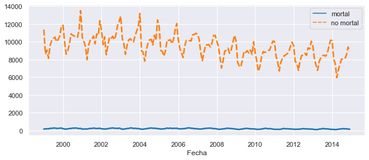

```python
sns.set(rc={'figure.figsize':(10, 4)})
sns.set_theme(style="darkgrid")
sns.lineplot(data=data_1, palette="tab10", linewidth=2.5)
```

Vamos a ver la evolución de los accidentes en el período comprendido entre 1999 y 2014. La tendencia tal y como dice el informe de accidentes de Canadá es decreciente. Si que observamos una fuerte estacionalidad entre los periodos de la serie.

Hay una gran discrepancia entre las dos series. Lo veremos en el análisis de la variable objeto `C_sev`. Ploteamos la evolución de cada serie por separado.

#### 1.1.1 ACCIDENTES ANUALES

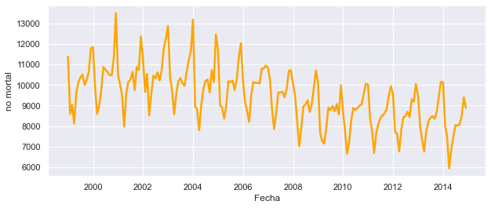

```python
sns.set(rc={'figure.figsize':(10, 4)})
sns.set_theme(style="darkgrid")
sns.lineplot(data=data_1["no mortal"], palette="tab10", linewidth=2.5, color="orange")
```

Vemos como hay una cierta estacionalidad en los datos, que se repite cada año un comportamiento parecido, mantenioéndose constante con una tendencia bajista. Analizaremos en detalle ver en qué meses se produce.

#### 1.1.2 MORTALIDAD ANUAL

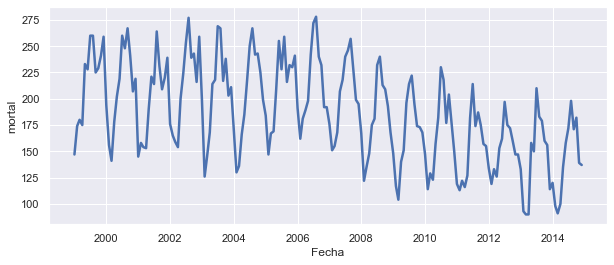

```python
sns.set(rc={'figure.figsize':(10, 4)})
sns.set_theme(style="darkgrid")
sns.lineplot(data=data_1["mortal"], palette="tab10", linewidth=2.5)
```

La mortalidad esta muy correlaccionada con los accidentes, de manera logica vemos como tiene una tendencia decreciente con un comportamiento estacional.

#### 2.0. ¿EN QUE CARRETERAS ES MAS PROPENSO TENER ACCIDENTES?

#### 2.1. ANÁLISIS TRAMOS DE LA CARRETERA

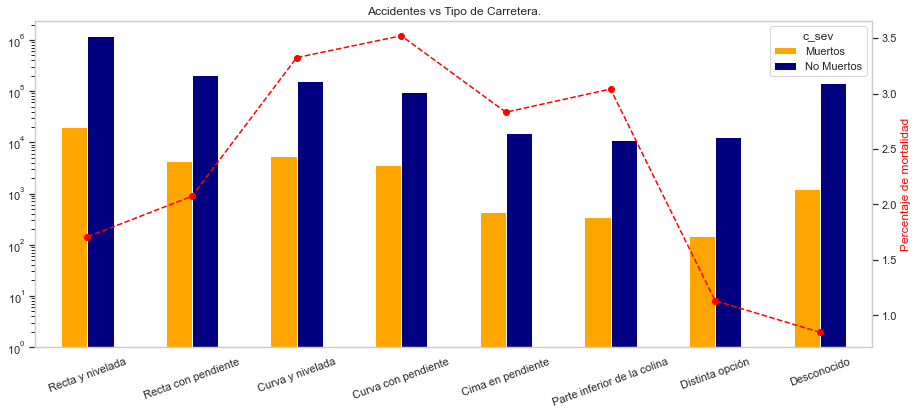

```python
data_2 = df_acc_p[["c_raln", "c_sev"]].set_index("c_raln")
data_2 = data_2.groupby(["c_raln","c_sev"]).size().unstack()
data_2 = data_2.set_axis(["Recta y nivelada", "Recta con pendiente", "Curva y nivelada", "Curva con pendiente","Cima en pendiente", "Parte inferior de la colina", "Distinta opción", "Desconocido"], axis='index')
data_2 = data_2.rename(columns={1: 'Muertos', 2: 'No Muertos'})

'''Dibujamos el grafico para mostrar la relacción de accidentes con tipo de carretera'''

plot_analisis(data_2, "Accidentes vs Tipo de Carretera.", 20)
```

#### 3.0. ANALISIS ACCIDENTES DIAS DE LA SEMANA

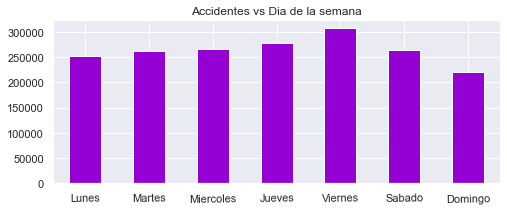

```python
data_3 = df_acc_p[["c_wday", "c_sev"]].set_index("c_wday")
data_3 = data_3.groupby(["c_wday"])["c_sev"].count()
data_3 = data_3.set_axis(["Lunes","Martes","Miercoles","Jueves","Viernes","Sabado","Domingo"], axis="index")
data_3.plot(kind="bar",rot=1,color= "darkviolet", figsize=(8,3),
         title='Accidentes vs Dia de la semana')
```

En conclusion, no se muestran muchas diferencias entre los accidentes semanales, sin embargo, si tenemos un pico en el viernes. Seguiremos haciendo estudios mas adelante, sobre la edad y el dia de la semana que nos puedan otorgar algo mas de luz sobre nuestro dataset.

#### 4. ANALISIS FALLECIDOS DIAS DE LA SEMANA

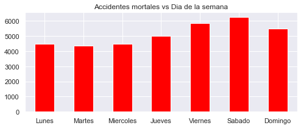

```python
data_4 = df_acc_p[["c_wday", "mortal"]].set_index("c_wday")
data_4 = data_4.groupby(["c_wday"])["mortal"].sum()
data_4 = data_4.set_axis(["Lunes","Martes","Miercoles","Jueves","Viernes","Sabado","Domingo"], axis="index")
data_4.plot(kind="bar",rot=0,color= "red", figsize=(8,3),
         title='Accidentes mortales vs Dia de la semana')
```

En la mortalidad si que se aprecia una diferencia visible entre los dias entresemana y los fin de semana, donde hay mucha mas mortalidad en los accidentes. Analizaremos mas adelante por que se debe esta situación, seguramente tenga que ver con el tipo de colision los fin de semana.

#### 5.0. ANALISIS ACCIDENTES POR MESES

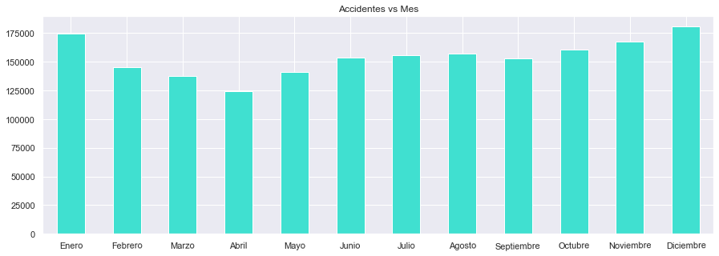

```python
data_5 = df_acc_p[["c_mnth", "c_sev"]].set_index("c_mnth")
data_5 = data_5.groupby(["c_mnth"])["c_sev"].count()
data_5 = data_5.set_axis(["Enero","Febrero","Marzo","Abril","Mayo","Junio","Julio","Agosto","Septiembre", "Octubre",
                         "Noviembre", "Diciembre"], axis="index")
data_5.plot(kind="bar",rot=1,color= "turquoise", figsize=(15,5),
         title='Accidentes vs Mes')
```

#### 6.0. ANALISIS ACCIDENTES POR HORAS

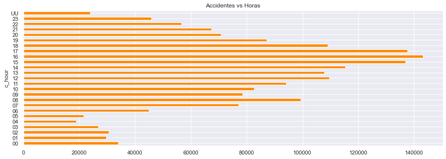

```python
data_6 = df_acc_p[["c_hour", "c_sev"]].set_index("c_hour")
data_6 = data_6.groupby(["c_hour"])["c_sev"].count()
data_6.plot(kind="barh",rot=1,color= "darkorange", figsize=(15,5),
         title='Accidentes vs Horas')
```

Esta representación gráfica de las horas es muy ilustrativa, ya que indica claramente en qué horas se producen más accidentes. En las horas de máxima aglomeración de vehículos, que suelen ser en las horas de salir del trabajo a casa, es cuando más accidentes se producen. De hecho una vez que es mitad de tarde, se ve un ligero descenso en los accidentes, debido a una reducción de la circulación. Esto se ve muy claro con las horas nocturnas, en las que la circulación en las carreteras es mínima y por lo tanto hay muy pocos accidentes. Tenemos una variable UU que desconocemos pero que no indica una gran cantidad de accidentes. Solo hay que destacar por último que las 8 de la mañana es una hora en la que se eleva el número de accidentes, condicionada por la hora de entrada al trabajo, es evidente que son horas puntas y que por lo tanto a un mayor número de coches circulando por las carreteras aumentan el número de accidentes que se producen.

#### 7.0. ¿EN QUÉ TIPOS DE CLIMA ES MÁS PROPENSO TENER ACCIDENTES?

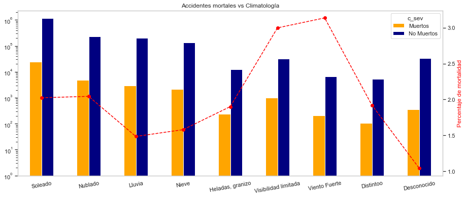

```python
data_7 = df_acc_p[["c_wthr", "c_sev"]].set_index("c_wthr")
data_7 = data_7.groupby(["c_wthr", "c_sev"]).size().unstack()
data_7 = data_7.set_axis(["Soleado","Nublado","Lluvia","Nieve","Heladas, granizo","Visibilidad limitada",
                          "Viento Fuerte", "Distintoo", "Desconocido"], axis="index")
data_7 = data_7.rename(columns={1: 'Muertos', 2: 'No Muertos'})

'''Dibujamos el grafico'''

plot_analisis(data_7, "Accidentes mortales vs Climatología", 10)
```

La climatologia nos puede arrojar mayor visibilidad sobre la mortalidad de un accidente o no. Aqui la diferencia no es tan grande en cuanto a la disposición del dataset, esto se debe en mayor medida al clima de Canadá. El mayor numero de accidente se tiene durante un dia soleado, sin embargo, la mortalidad de estos es bastante mas pequeña que en un dia con visibilidad reducida (niebla,etc), y con visbilidad limitada y viento fuerte.

Destacamos tambien que esta variable tiene muchos valores desconocidos y distintos, por lo que tendremos que decisión tomar con estos datos.

#### 8.0. ¿EN QUÉ CONDICIONES DE LA CARRETERA ES MÁS PROPENSO TENER ACCIDENTES?

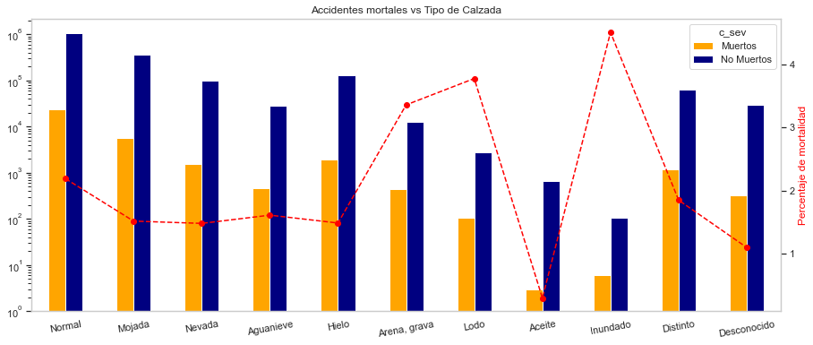

```python
data_8 = df_acc_p[["c_rsur", "c_sev"]].set_index("c_rsur")
data_8 = data_8.groupby(["c_rsur", "c_sev"]).size().unstack()
data_8 = data_8.set_axis(["Normal","Mojada", "Nevada", "Aguanieve", "Hielo", "Arena, grava", "Lodo",
                         "Aceite", "Inundado", "Distinto", "Desconocido"], axis="index")
data_8 = data_8.rename(columns={1: 'Muertos', 2: 'No Muertos'})

'''Dibujamos el grafico'''

plot_analisis(data_8, "Accidentes mortales vs Tipo de Calzada", 10)
```

Nos llama mucho la atención que la superficie con mayor mortalidad sea la inundada. Puede ser debido a posibles outliers. También puede referirse a ciertas inundaciones que se produzcan en tramos de carretera y que esto conlleva a momentos de peligro en el que el conductor se puede ver atrapado por el agua en el vehículo e incluso fallecer porque le arrastre una corriente de agua o ahogado. Además destacamos un aumento significativo de la mortalidad en superficies como arena, grava y lodo, debido a posibles deslizamientos del vehículo que provoque un accidente grave.

Volvemos a tener un porcentaje bastante elevado de superficies desconocidas.

#### 9. TRAMO DE LA CARRETERA EN EL QUE ES MÁS PROPENSO TENER ACCIDENTES

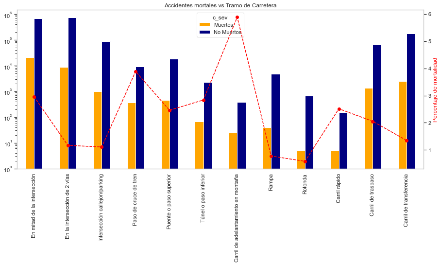

```python
data_9 = df_acc_p[["c_rcfg", "c_sev"]].set_index("c_rcfg")
data_9 = data_9.groupby(["c_rcfg", "c_sev"]).size().unstack()
data_9 = data_9.set_axis(["En mitad de la intersección", "En la intersección de 2 vías", "Intersección callejon/parking",
                           "Paso de cruce de tren", "Puente o paso superior", "Túnel o paso inferior", "Carril de adelantamiento en montaña",
                           "Rampa", "Rotonda", "Carril rápido", "Carril de traspaso", "Carril de transferencia"], axis="index")
data_9 = data_9.rename(columns={1: 'Muertos', 2: 'No Muertos'})

'''Dibujamos el grafico'''

plot_analisis(data_9, "Accidentes mortales vs Tramo de Carretera", 90)
```

El tramo de carretera no determina que sea un factor determinante en la mortalidad, puesto que en el gráfico no se ve salvo una variable que influya en el porcentaje de mortalidad. Es lógico que esta variable sea el carril de adelantamiento de la carretera en montaña ya que se puede producir por un aumento de la velocidad, que provoque un exceso de velocidad y un menor tiempo de reacción, en el que el impacto obviamente es mayor y más mortal. El paso de cruce de tren es otra variable a destacar en el que también hay un porcentaje alto de mortalidad respecto al resto, ya que un accidente en esta zona es mortal, debido al arrollamiento por parte del tren al vehículo

#### 10. ELEMENTOS DE SEÑALIZACIÓN DEL TRÁFICO VS ACCIDENTES

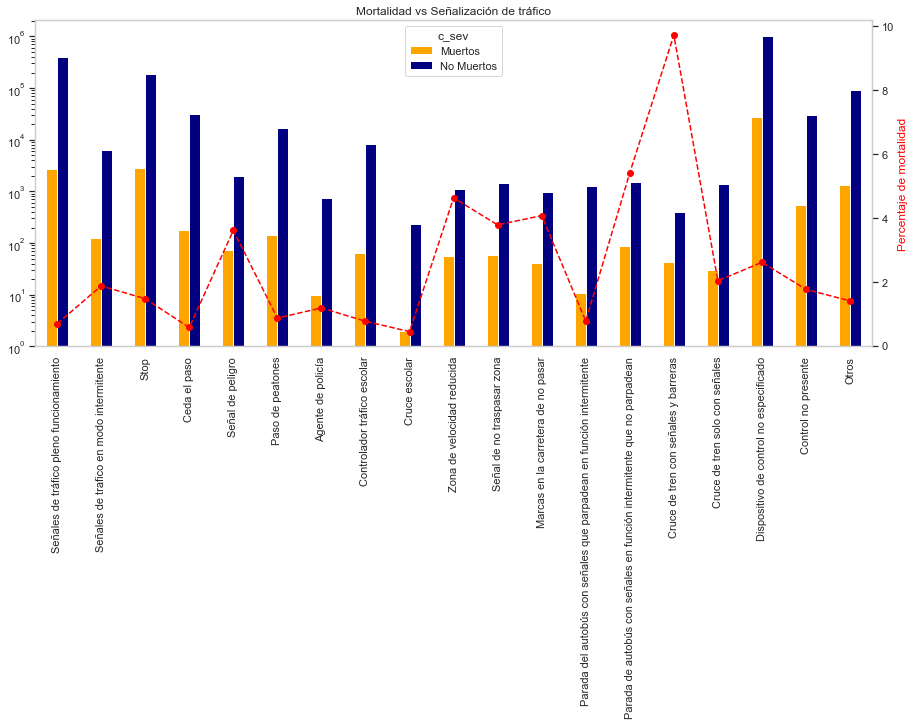

```python
data_10 = df_acc_p[['c_traf', 'c_sev']].set_index('c_traf')
data_10 = data_10.groupby(['c_traf', 'c_sev']).size().unstack()
data_10 = data_10.set_axis(['Señales de tráfico pleno funcionamiento','Señales de trafico en modo intermitente', 'Stop','Ceda el paso',
                           'Señal de peligro', 'Paso de peatones', 'Agente de policía', 'Controlador tráfico escolar', 'Cruce escolar',
                           'Zona de velocidad reducida', 'Señal de no traspasar zona', 'Marcas en la carretera de no pasar',
                           'Parada del autobús con señales que parpadean en función intermitente', 'Parada de autobús con señales en función intermitente que no parpadean',
                           'Cruce de tren con señales y barreras', 'Cruce de tren solo con señales', 'Dispositivo de control no especificado',
                            'Control no presente', 'Otros'])

data_10 = data_10.rename(columns={1:'Muertos', 2: 'No Muertos'})

'''Dibujamos el grafico'''

plot_analisis(data_10, "Mortalidad vs Señalización de tráfico", 90)
```

Las señales de tráfico incluyen tanto las señales como elementos que puedan influenciar en el tráfico, ya sea un policía que esté controlando el tráfico o un controlador del tráfico de un colegio para que los niños puedan acceder a la escuela sin ningún problema. Hay cierta igualdad de muertes entre las variables, destacando la variable de dispositivo de control no especificado, que no indica cuál puede ser, pero se producen bastantes accidentes y muertes. Una zona con un alto porcentaje de mortalidad es el cruce del tren con barreras, donde un accidente por arrollamiento de tren es mortal. Por lo que es lógico que sea alto el porcentaje en esa variable. También es descatable la zona de velocidad reducida, ya que por ese caso sea por un exceso de velocidad.

#### 11. TIPO DE ACCIDENTE Y MORTALIDAD

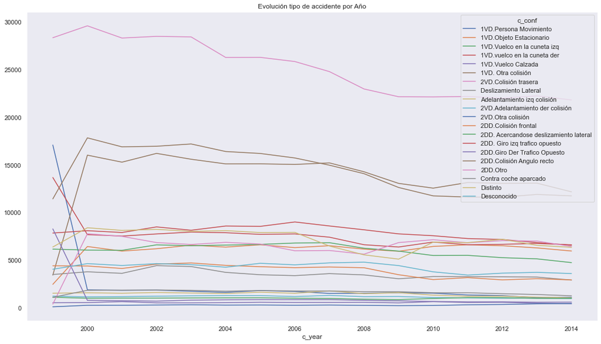

```python
data_11 = df_acc_p[["c_year", "c_conf"]]
data_11 = data_11.groupby(["c_year", "c_conf"]).size().unstack()
data_11 = data_11.rename(columns={"01":"1VD.Persona Movimiento", "02": "1VD.Objeto Estacionario", "03":"1VD.Vuelco en la cuneta izq",
                                 "04": "1VD.vuelco en la cuneta der", "05": "1VD.Vuelco Calzada", "06": "1VD. Otra colisión",
                                 "21": "2VD.Colisión trasera", "22": "Deslizamiento Lateral", "23": "Adelantamiento izq colisión",
                                 "24": "2VD.Adelantamiento der colisión", "25": "2VD.Otra colisión", "31": "2DD.Colisión frontal",
                                 "32": "2DD. Acercandose deslizamiento lateral", "33": "2DD. Giro izq trafico opuesto",
                                 "34": "2DD.Giro Der Trafico Opuesto", "35": "2DD.Colisión Angulo recto", "36": "2DD.Otro",
                                 "41": "Contra coche aparcado","QQ": "Distinto", "UU": "Desconocido"})

'''Dibujamos el grafico'''

fig,ax1 = plt.subplots()
ax1.tick_params(grid_alpha=0)
data_11.plot(figsize=(18,10),title='Evolución tipo de accidente por Año', ax=ax1)
```

Podemos ver como el impacto mas común es la colisión por acercamiento. Esto nos revela un problema en el trafico de Canada, no se respecta la distancia de seguridad entre coche y coche. La siguiente colisión mas usual es la de ángulo recto. Una colisión frontal que aventuramos producirá mas muertos que la colisión por alcance. Lo estudiamos ahora:

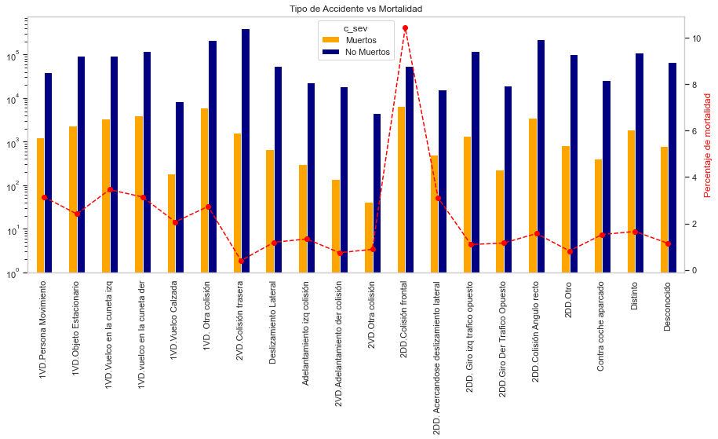

```python
data_12 = df_acc_p[["c_conf", "c_sev"]].set_index("c_conf")
data_12 = data_12.groupby(["c_conf", "c_sev"]).size().unstack()
data_12 = data_12.set_axis(["1VD.Persona Movimiento", "1VD.Objeto Estacionario", "1VD.Vuelco en la cuneta izq",
                                 "1VD.vuelco en la cuneta der", "1VD.Vuelco Calzada", "1VD. Otra colisión",
                                 "2VD.Colisión trasera", "Deslizamiento Lateral", "Adelantamiento izq colisión",
                                 "2VD.Adelantamiento der colisión", "2VD.Otra colisión", "2DD.Colisión frontal",
                                 "2DD. Acercandose deslizamiento lateral", "2DD. Giro izq trafico opuesto",
                                 "2DD.Giro Der Trafico Opuesto", "2DD.Colisión Angulo recto", "2DD.Otro",
                                 "Contra coche aparcado","Distinto", "Desconocido"], axis="index")

data_12 = data_12.rename(columns={1: 'Muertos', 2: 'No Muertos'})

'''Dibujamos el grafico'''

plot_analisis(data_12, "Tipo de Accidente vs Mortalidad", 90)
```

Los dos accidentes que mas destacan son la colision trasera y en angulo recto, sin embargo, queremos destacar que el procentaje de mortalidad de la colisión trasera o por alcance es muy inferior a la del resto de colisiones. En este sentido, la colisión más mortal, es la colisión frontal. De cara a nuestro modelo, el tipo de colisión será muy importante para determinar si hay fallecidos o no. Especialmente sera significativa la colisión frontal.

#### 12. TIPO DE ACCIDENTE Y PERSONAS INVOLUCRADAS

Hacer un boxplot de las 2 variables, para ver los outliers.

Analizar de los outliers que te salga la incidencia que tiene.

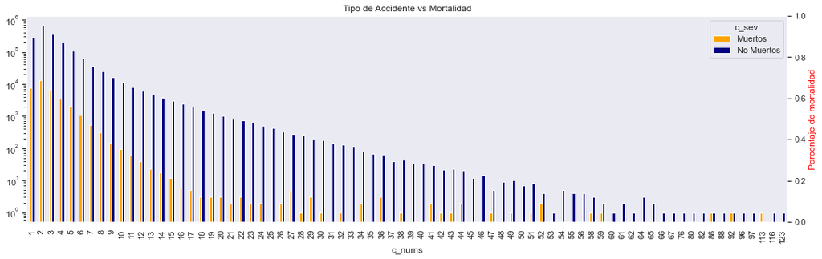

```python
data_13 = df_acc_p[["c_nums", "c_sev"]].set_index("c_nums")
data_13 = data_13.groupby(["c_nums", "c_sev"]).size().unstack()

data_13 = data_13.rename(columns={1: 'Muertos', 2: 'No Muertos'})

'''Dibujamos el grafico'''

fig,ax1 = plt.subplots()
ax1.tick_params(grid_alpha=0)
ax2 = ax1.twinx()
ax2.set_ylabel('Porcentaje de mortalidad', color="red")
ax2.tick_params(grid_alpha=0)

data_13.plot(kind="bar", log=True, color=['orange','navy'], figsize=(18,5),
         title='Tipo de Accidente vs Mortalidad', ax=ax1)
```

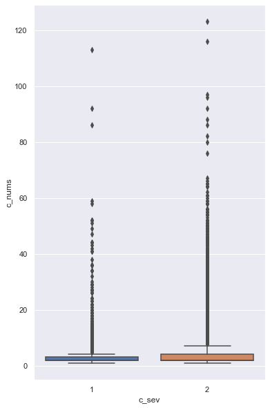

```python
sns.set(rc={'figure.figsize':(6, 10)})
# ax = sns.boxplot(x="c_sev", y="c_nums", data=df_acc_p)
sns.boxplot(x = "c_sev", y="c_nums", data=df_acc_p)
```

Podemos observar que en en el caso de csev = 2, cuando se trata de no muertos, hay un mayor número de outliers. Valores extremos que habrá que analizar para saber qué importancia aportan a nuestro dataset.